# Convergence in Probability

Paul Schrimpf

2026-10-26

## Reading

- Required: **Song (2021) chapter 9**
- Independent study: Song (2021) chapters 6-7

# Convergence in Probability

$$\def\Er{{\mathrm{E}}}
\def\En{{\mathbb{En}}}
\def\cov{{\mathrm{Cov}}}
\def\var{{\mathrm{Var}}}
\def\R{{\mathbb{R}}}
\newcommand\norm[1]{\left\lVert#1\right\rVert}
\def\rank{{\mathrm{rank}}}
\newcommand{\inpr}{ \overset{p^*_{\scriptscriptstyle n}}{\longrightarrow}}
\def\inprob{{\,{\buildrel p \over \rightarrow}\,}}
\def\indist{\,{\buildrel d \over \rightarrow}\,}
\DeclareMathOperator*{\plim}{plim}$$

## Convergence in Probability

**Definition**

Random vectors $X_1, X_2, ...$ **converge in probability** to the random vector $Y$ if for all $\epsilon>0$
$$\lim_{n \to \infty} P\left( \norm{X_n - Y} > \epsilon \right) = 0$$
denoted by $X_n \inprob Y$ or $\plim_{n \to \infty} X_n = Y$

- Typical use: $X_n = \hat{\theta}_n$, estimator from $n$ observations, $Y=\theta_0$, a constant.
- How to show that $\hat{\theta}_n \inprob \theta_0$?

## $L^p$ convergence

**Definition**

Random vectors $X_1, X_2, ...$ **converge in $L^p$** to the random vector $Y$ if
$$\lim_{n \to \infty} \Er\left[ \norm{X_n-Y}^p \right] = 0$$

- $p=2$ called convergence in mean square

## Markov’s Inequality

**Markov’s Inequality**

$P(|X|>\epsilon) \leq \frac{\Er[|X|^k]}{\epsilon^k}$ $\forall \epsilon > 0, k > 0$

- $P\left( \norm{X_n - Y} > \epsilon \right) \leq \frac{\Er[ \norm{X_n - Y}^k]} {\epsilon^k}$

## Convergence in $L^p$ implies convergence in probability

**Theorem 1.1**

If $X_n$ converges in $L^p$ to $Y$, then $X_n \inprob Y$.

## Application to Estimators

- An estimator, $\hat{\theta}$ is **consistent** if $\hat{\theta} \inprob \theta_0$
- Implication for estimators:
  $$\begin{aligned}
  MSE(\hat{\theta}_n) = & \Er[ \norm{\hat{\theta}_n - \theta_0}^2 ] \\
  = & tr[\var(\hat{\theta}_n)] + Bias(\hat{\theta}_n)'Bias(\hat{\theta}_n)
  \end{aligned}$$
- If $MSE(\hat{\theta}_n) \to 0$, then $\hat{\theta}_n \inprob \theta_0$
- If $\lim_{n \to \infty} \Er[\hat{\theta}_n] \neq \theta_0$, then $\plim \hat{\theta}_n \neq \theta_0$

## Consistency of Least-Squares

- In $y = X \beta_0 + u$, when does $\hat{\beta} = (X'X)^{-1} X' y$ $\inprob \beta_0$?
- Sufficient that $MSE(\hat{\beta}) = tr[\var(\hat{\beta})] + Bias(\hat{\beta})'Bias(\hat{\beta}) \to 0$
- $\var(\hat{\beta}) = \Er[\var(\hat{\beta}|X)] + \var(\Er[\hat{\beta}|X]) = \sigma^2 \Er[(X'X)^{-1}] + 0$
- $tr((X'X)^{-1}) \leq \frac{k}{\lambda_{\min}(X'X)}$

## Convergence in Probability of Functions

**Theorem 2.2**

If $X_n \inprob X$, and $f$ is continuous, then $f(X_n) \inprob f(X)$

**Slutsky’s Lemma**

If $Y_n \inprob c$ and $W_n \inprob d$, then

- $Y_n + W_n \inprob c+ d$
- $Y_n W_n \inprob cd$
- $Y_n / W_n \inprob c/d$ if $d \neq 0$

## Weak Law of Large Numbers

**Weak Law of Large Numbers**

If $X_1, ..., X_n$ are i.i.d. and $\Er[X^2]$ exists, then
$$\frac{1}{n} \sum X_i \inprob \Er[X]$$

- Proof: use Markov’s inequality
- This is the simplest to prove WLLN, but there are many variants with alternate assumptions that also imply $\frac{1}{n} \sum X_i \inprob \Er[X]$

## Consistency of Least Squares Revisited

- In $y = X \beta_0 + u$, when does $\hat{\beta} \inprob \beta_0$?
- $\hat{\beta} = \left(\frac{1}{n} \sum_{i=1}^n X_i X_i' \right)^{-1} \left(\frac{1}{n} \sum_{i=1}^n X_i y_i \right)$
- If WLLN applies to $\frac{1}{n} \sum_{i=1}^n X_i X_i'$ and $\frac{1}{n} \sum_{i=1}^n X_i y_i$ (and $\Er[X_i X_i']^{-1}$ exists)
- Sufficient for i.i.d, $\Er[X_i u_i] = 0$, 4th moments of $X_i$ to exist, $\Er[u_i^2]$ to exist

# Convergence Rates

## Convergence Rates

**Definition**

Given a sequence of random variables, $X_1, X_2, ...$ and constants $b_1, b_2, ...$, then

- $X_n = O_p(b_n)$ if for all $\epsilon > 0$ there exists $M_\epsilon$ s.t.
  $$\limsup P\left(\frac{\norm{X_n}}{b_n} \geq M_\epsilon \right) < \epsilon$$
- $X_n = o_p(b_n)$ if $\frac{X_n}{b_n} \inprob 0$

## Example: Little $o_p$

- Real valued $X_1, ..., X_n$ i.i.d., with $\Er[X] = \mu$, $\var(X_i) = \sigma^2$
- Markov’s inequality
  $$P\left( |\overbrace{\En X_i}^{\equiv \frac{1}{n} \sum_{i=1}^n X_i} - \mu | > a \right) \leq \frac{\var(\En X_i - \mu)}{a^2} \leq \frac{\sigma^2}{n a^2}$$
- Let $a = \epsilon n^{-\alpha}$, then
  $$P\left( \frac{|\En X_i - \mu |}{n^{-\alpha}} > \epsilon \right) \leq \frac{\sigma^2}{n^{1 - 2\alpha}\epsilon^2}$$
- $|\En X_i - \mu | = o_p(n^{-\alpha})$ for $\alpha \in (0, 1/2)$

## Example: Big $O_p$

- Real valued $X_1, ..., X_n$ i.i.d., with $\Er[X] = \mu$, $\var(X_i) = \sigma^2$
- Markov’s inequality
  $$P\left( |\overbrace{\En X_i}^{\equiv \frac{1}{n} \sum_{i=1}^n X_i} - \mu | > a \right) \leq \frac{\var(\En X_i - \mu)}{a^2} \leq \frac{\sigma^2}{n a^2}$$
- Let $a = \sigma \epsilon^{-1/2} n^{-1/2}$,
  $$P\left( \frac{|\En X_i - \mu |}{n^{-1/2}} > \underbrace{\sigma \epsilon^{-1/2}}_{M_\epsilon} \right) \leq \epsilon$$
  so $|\En X_i - \mu | = O_p(n^{-\alpha})$ for $\alpha \in (0, 1/2]$

## Simulation of Stochastic Order

- $\frac{1}{n} \sum_{i=1}^n x_i = O_p(n^{-1/2})$ means that by scaling the red line by $M_\epsilon$, we can make the probability of the blue lines being above it less than $\epsilon$

```julia
using Distributions, Plots, Statistics, Random, LaTeXStrings
Random.seed!(1234)
S = 100
n = 2:400
distribution = Exponential(1)
dgp(n) = rand(distribution, n)
μ = mean(distribution)
fig = plot()
for s in 1:S
    data = dgp(maximum(n))
    plot!(fig, n, abs.(mean.(data[1:i] for i in n) .- μ), alpha=0.2, label=false, color=:blue)
end
plot!(fig, n, 1 ./ sqrt.(n), label=L"n^{-1/2}", color=:red, lw=3)
fig
```

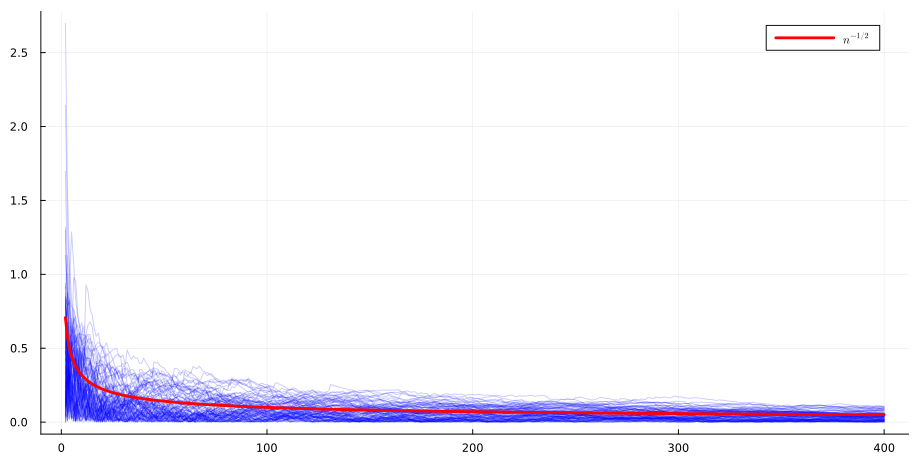

## Simulation of Stochastic Order

```julia
using Distributions, Plots, Statistics, Random, LaTeXStrings
Random.seed!(1234)
S = 100
n = 2:400
distribution = Exponential(1)
dgp(n) = rand(distribution, n)
m₀ = minimum(distribution)
fig = plot()
for s in 1:S
    data = dgp(maximum(n))
    plot!(fig, n, abs.(minimum.(data[1:i] for i in n) .- m₀), alpha=0.2, label=false, color=:blue)
end
plot!(fig, n, 1 ./ sqrt.(n), label=L"n^{-1/2}", lw=3)
plot!(fig, n, 1 ./(n), label=L"n^{-1}", lw=3)
ylims!(fig, (0, 1/sqrt(10)))
fig
```

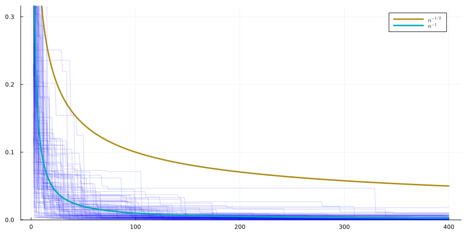

## Big $O$ and little $o$ calculus

- If $X_n = o_p(a_n)$ and $Y_n=o_p(b_n)$, then
  - $X_n + Y_n = o_p(\max\{a_n,b_n\})$
  - $|X_n'Y_n| = o_p(a_n b_n)$
- If $X_n = O_p(a_n)$ and $Y_n=O_p(b_n)$, then
  - $X_n + Y_n = O_p(\max\{a_n,b_n\})$
  - $|X_n'Y_n| = O_p(a_n b_n)$

# Non-Asymptotic Bounds

## Non-Asymptotic Bounds: Chernoff Bound

- Let $\Er[X] = \mu$
- Markov’s inequality: $P(|X - \mu |>\epsilon) \leq \frac{\Er[|X - \mu|^k]}{\epsilon^k}$ $\forall \epsilon > 0, k > 0$
- Idea: minimize right side over $k$ to get a tighter bound
- **Chernoff bound technique**: apply Markov’s inequality to the exponential $e^{\lambda(X-\mu)}$ for $\lambda > 0$

## Non-Asymptotic Bounds: Sub-Gaussian Variables

- Markov’s inequality for $e^{\lambda(X-\mu)}$:
  $$P(X-\mu>\epsilon) = P\left( e^{\lambda (X - \mu)} > e^{\lambda \epsilon} \right) \leq e^{-\lambda \epsilon} \Er\left[e^{\lambda (X-\mu)}\right]$$
- $M_{X-\mu}(\lambda)=\Er\left[e^{\lambda (X-\mu)}\right]$ is the (centered) moment generating function
- $X$ is **sub-Gaussian** with variance proxy $\sigma^2$ if $\Er\left[e^{\lambda (X-\mu)}\right] \leq e^{\frac{\lambda^2 \sigma^2}{2}}$
  - Normal distribution: if $X \sim N(\mu, \sigma^2)$, then $\Er\left[e^{\lambda (X-\mu)}\right] = e^{\frac{\lambda^2 \sigma^2}{2}}$
  - Bounded variables (**Hoeffding’s Lemma**): if $|X| \leq b$, then $\Er\left[e^{\lambda (X-\mu)}\right] \leq e^{\lambda^2 b^2}$

## Non-Asymptotic Bounds: Sub-Gaussian Concentration

- **Chernoff bound for sub-Gaussian variable**:
  $$P(X-\mu>\epsilon) \leq \inf_{\lambda \geq 0} e^{-\lambda \epsilon + \lambda^2 \sigma^2/2} = e^{-\frac{\epsilon^2}{2 \sigma^2}}$$
- **Hoeffding-type inequality for sample means**: if $X_1, \dots, X_n$ are independent and sub-Gaussian($\sigma^2$), then $\frac{1}{n}\sum_{i=1}^n X_i - \mu$ is sub-Gaussian($\sigma^2/n$):
  $$P\left(\frac{1}{n} \sum_{i=1}^n X_i-\mu >\epsilon\right) \leq e^{-\frac{\epsilon^2 n}{2 \sigma^2}}$$

## Application: Generalization Bound

- Given $\hat{\beta} = \mathrm{arg}\min \frac{1}{n} \sum_{i=1}^n \ell( y_i, x_i; \beta)$, can we bound
  $$\Er[\ell(y_i,x_i;\hat{\beta})]?$$
- Yes, under reasonable assumptions, we can show
  $$P\left( \Er[\ell(Y,X;\beta)] \geq \frac{1}{n} \sum_{i=1}^n \ell \left(y_i, x_i;\beta \right) + \sqrt{\frac{C_0 + C_1 \log(1/\delta) + k/2\log(n)}{n}} \forall \beta \in \mathscr{B} \right) \leq \delta$$
- To show use:
  - Non-asymptotic bound for fixed $\beta$ from above
  - Union-bound argument over finitely many different values of $\beta$
  - Compactness to approximate infinite values of $\beta$ with finite set ($\epsilon$-net / covering)

# References

Song, Kyunchul. 2021. *Introduction to Econometrics*.